# SL_Project_Walmart_RetailAnalysis

```python
import pandas as pd
import numpy as py
import math
import matplotlib.pyplot as plt
import seaborn as sns
from matplotlib import style
%matplotlib inline
```

```python
df = pd.read_csv('Walmart_Store_sales.csv')
df1 = pd.read_csv('Walmart_Store_sales.csv')
df2 = pd.read_csv('Walmart_Store_sales.csv')
```

```python
df1.describe()
```

|  | Store | Weekly_Sales | Holiday_Flag | Temperature | Fuel_Price | CPI | Unemployment |
| --- | --- | --- | --- | --- | --- | --- | --- |
| count | 6435.000000 | 6.435000e+03 | 6435.000000 | 6435.000000 | 6435.000000 | 6435.000000 | 6435.000000 |
| mean | 23.000000 | 1.046965e+06 | 0.069930 | 60.663782 | 3.358607 | 171.578394 | 7.999151 |
| std | 12.988182 | 5.643666e+05 | 0.255049 | 18.444933 | 0.459020 | 39.356712 | 1.875885 |
| min | 1.000000 | 2.099862e+05 | 0.000000 | -2.060000 | 2.472000 | 126.064000 | 3.879000 |
| 25% | 12.000000 | 5.533501e+05 | 0.000000 | 47.460000 | 2.933000 | 131.735000 | 6.891000 |
| 50% | 23.000000 | 9.607460e+05 | 0.000000 | 62.670000 | 3.445000 | 182.616521 | 7.874000 |
| 75% | 34.000000 | 1.420159e+06 | 0.000000 | 74.940000 | 3.735000 | 212.743293 | 8.622000 |
| max | 45.000000 | 3.818686e+06 | 1.000000 | 100.140000 | 4.468000 | 227.232807 | 14.313000 |

```python
df1.head()
```

|  | Store | Date | Weekly_Sales | Holiday_Flag | Temperature | Fuel_Price | CPI | Unemployment |
| --- | --- | --- | --- | --- | --- | --- | --- | --- |
| 0 | 1 | 05-02-2010 | 1643690.90 | 0 | 42.31 | 2.572 | 211.096358 | 8.106 |
| 1 | 1 | 12-02-2010 | 1641957.44 | 1 | 38.51 | 2.548 | 211.242170 | 8.106 |
| 2 | 1 | 19-02-2010 | 1611968.17 | 0 | 39.93 | 2.514 | 211.289143 | 8.106 |
| 3 | 1 | 26-02-2010 | 1409727.59 | 0 | 46.63 | 2.561 | 211.319643 | 8.106 |
| 4 | 1 | 05-03-2010 | 1554806.68 | 0 | 46.50 | 2.625 | 211.350143 | 8.106 |

**Question:Which store has maximum sales

```python
#grp1 = df1.groupby(['Store','Weekly_Sales'])['Weekly_Sales'].sum()
grp2 = df1.groupby('Store')['Weekly_Sales'].sum()
```

```python
grp2.max()
```

```
301397792.46000004
```

```python
grp2.idxmax()
```

```
20
```

# Store 20 has the highest sales.

**Question: Which store has maximum standard deviation i.e., the sales vary a lot. Also, find out the coefficient of mean to standard deviation

```python
grp3 = df1.groupby('Store').agg({'Weekly_Sales': ['std']})
```

```python
grp3.max()
```

```
Weekly_Sales  std    317569.949476
dtype: float64
```

```python
grp3.idxmax()
```

```
Weekly_Sales  std    14
dtype: int64
```

Store 14 has highest Standard Deviation

```python
#grp4 = df1.groupby('Store',as_index=False).agg({'Weekly_Sales': ['mean','std']})
grp4 = df1.groupby('Store').agg({'Weekly_Sales': ['mean','std']})
```

```python
grp4
```

| Store | Weekly_Sales mean | Weekly_Sales std |
| --- | --- | --- |
| 1 | 1.555264e+06 | 155980.767761 |
| 2 | 1.925751e+06 | 237683.694682 |
| 3 | 4.027044e+05 | 46319.631557 |
| 4 | 2.094713e+06 | 266201.442297 |
| 5 | 3.180118e+05 | 37737.965745 |
| 6 | 1.564728e+06 | 212525.855862 |
| 7 | 5.706173e+05 | 112585.469220 |
| 8 | 9.087495e+05 | 106280.829881 |
| 9 | 5.439806e+05 | 69028.666585 |
| 10 | 1.899425e+06 | 302262.062504 |
| 11 | 1.356383e+06 | 165833.887863 |
| 12 | 1.009002e+06 | 139166.871880 |
| 13 | 2.003620e+06 | 265506.995776 |
| 14 | 2.020978e+06 | 317569.949476 |
| 15 | 6.233125e+05 | 120538.652043 |
| 16 | 5.192477e+05 | 85769.680133 |
| 17 | 8.935814e+05 | 112162.936087 |
| 18 | 1.084718e+06 | 176641.510839 |
| 19 | 1.444999e+06 | 191722.638730 |
| 20 | 2.107677e+06 | 275900.562742 |
| 21 | 7.560691e+05 | 128752.812853 |
| 22 | 1.028501e+06 | 161251.350631 |
| 23 | 1.389864e+06 | 249788.038068 |
| 24 | 1.356755e+06 | 167745.677567 |
| 25 | 7.067215e+05 | 112976.788600 |
| 26 | 1.002912e+06 | 110431.288141 |
| 27 | 1.775216e+06 | 239930.135688 |
| 28 | 1.323522e+06 | 181758.967539 |
| 29 | 5.394514e+05 | 99120.136596 |
| 30 | 4.385796e+05 | 22809.665590 |
| 31 | 1.395901e+06 | 125855.942933 |
| 32 | 1.166568e+06 | 138017.252087 |
| 33 | 2.598617e+05 | 24132.927322 |
| 34 | 9.667816e+05 | 104630.164676 |
| 35 | 9.197250e+05 | 211243.457791 |
| 36 | 3.735120e+05 | 60725.173579 |
| 37 | 5.189003e+05 | 21837.461190 |
| 38 | 3.857317e+05 | 42768.169450 |
| 39 | 1.450668e+06 | 217466.454833 |
| 40 | 9.641280e+05 | 119002.112858 |
| 41 | 1.268125e+06 | 187907.162766 |
| 42 | 5.564039e+05 | 50262.925530 |
| 43 | 6.333247e+05 | 40598.413260 |
| 44 | 3.027489e+05 | 24762.832015 |
| 45 | 7.859814e+05 | 130168.526635 |

```python
grp5 = df1.groupby('Store')['Weekly_Sales'].sum()
```

```python
grp5
```

```
Store
1     2.224028e+08
2     2.753824e+08
3     5.758674e+07
4     2.995440e+08
5     4.547569e+07
6     2.237561e+08
7     8.159828e+07
8     1.299512e+08
9     7.778922e+07
10    2.716177e+08
11    1.939628e+08
12    1.442872e+08
13    2.865177e+08
14    2.889999e+08
```

[output cut: 32 more lines]

```python
cv = lambda x: py.std(x, ddof=1) / py.mean(x) * 100
```

```python
cv(grp5)
```

```
52.21056416441267
```

THe Coeffecient variation of mean to standard deviation for Weekly sales(grouped by store) is 52.2

***Question:Which store/s has good quarterly growth rate in Q3’2012

```python
data_Q32012 = df1[(pd.to_datetime(df1['Date']) >= pd.to_datetime('07-01-2012')) &
                  (pd.to_datetime(df1['Date']) <= pd.to_datetime('09-30-2012'))]

q3 = data_Q32012.groupby(['Store'])['Weekly_Sales'].sum()
```

```python
data_Q22012 = df1[(pd.to_datetime(df1['Date']) >= pd.to_datetime('04-01-2012')) &
                  (pd.to_datetime(df1['Date']) <= pd.to_datetime('06-30-2012'))]

q2 = data_Q22012.groupby(['Store'])['Weekly_Sales'].sum()
```

```python
qq = ((q3 -q2)/q2) * 100
```

```python
qq.max()
```

```
-2.7892938117467203
```

```python
qq.idxmax()
```

```
16
```

Store 16 has the higest quarterly growth rate in Q3 2012, Still it is in minus which means all the stores faced only loss in Q3 2012, but store 16 has the least loss percentage which can be otherwise mentioned as highest growth rate among the stores.

*Question: Some holidays have a negative impact on sales. Find out holidays which have higher sales than the mean sales in non-holiday season for all stores together

```python
nonholiday_sales_mean = df1[df1['Holiday_Flag'] == 0]['Weekly_Sales'].mean()
```

```python
nonholiday_sales_mean
```

```
1041256.3802088564
```

```python
holiday_sales = df1[df1['Holiday_Flag'] == 1]
```

Superbowl holiday season sales analysis - Super Bowl: 12-Feb-10, 11-Feb-11, 10-Feb-12, 8-Feb-13

```python
SB1 = holiday_sales[pd.to_datetime(holiday_sales['Date']) == pd.to_datetime('12-2-2010')]['Weekly_Sales'].sum()
SB2 = holiday_sales[pd.to_datetime(holiday_sales['Date']) == pd.to_datetime('11-2-2011')]['Weekly_Sales'].sum()
SB3 = holiday_sales[pd.to_datetime(holiday_sales['Date']) == pd.to_datetime('10-2-2012')]['Weekly_Sales'].sum()
SB4 = holiday_sales[pd.to_datetime(holiday_sales['Date']) == pd.to_datetime('8-2-2013')]['Weekly_Sales'].sum()
```

```python
print(SB1,SB2,SB3,SB4)
```

```
48336677.63000002 47336192.79 50009407.92 0.0
```

Labour Day holiday season sales analysis - Labour Day: 10-Sep-10, 9-Sep-11, 7-Sep-12, 6-Sep-13

```python
LD1 = holiday_sales[pd.to_datetime(holiday_sales['Date']) == pd.to_datetime('10-9-2010')]['Weekly_Sales'].sum()
LD2 = holiday_sales[pd.to_datetime(holiday_sales['Date']) == pd.to_datetime('9-9-2011')]['Weekly_Sales'].sum()
LD3 = holiday_sales[pd.to_datetime(holiday_sales['Date']) == pd.to_datetime('7-9-2012')]['Weekly_Sales'].sum()
LD4 = holiday_sales[pd.to_datetime(holiday_sales['Date']) == pd.to_datetime('6-9-2013')]['Weekly_Sales'].sum()
```

```python
print(LD1,LD2,LD3,LD4)
```

```
45634397.84 46763227.529999994 48330059.309999995 0.0
```

ThanksGiving holiday season sales analysis - Thanksgiving: 26-Nov-10, 25-Nov-11, 23-Nov-12, 29-Nov-13

```python
TG1 = holiday_sales[pd.to_datetime(holiday_sales['Date']) == pd.to_datetime('26-11-2010')]['Weekly_Sales'].sum()
TG2 = holiday_sales[pd.to_datetime(holiday_sales['Date']) == pd.to_datetime('25-11-2011')]['Weekly_Sales'].sum()
TG3 = holiday_sales[pd.to_datetime(holiday_sales['Date']) == pd.to_datetime('23-11-2012')]['Weekly_Sales'].sum()
TG4 = holiday_sales[pd.to_datetime(holiday_sales['Date']) == pd.to_datetime('29-11-2013')]['Weekly_Sales'].sum()
```

```python
print(TG1,TG2,TG3,TG4)
```

```
65821003.24 66593605.26 0.0 0.0
```

Christmas holiday season sales analysis - Christmas: 31-Dec-10, 30-Dec-11, 28-Dec-12, 27-Dec-13

```python
CH1 = holiday_sales[pd.to_datetime(holiday_sales['Date']) == pd.to_datetime('31-12-2010')]['Weekly_Sales'].sum()
CH2 = holiday_sales[pd.to_datetime(holiday_sales['Date']) == pd.to_datetime('30-12-2011')]['Weekly_Sales'].sum()
CH3 = holiday_sales[pd.to_datetime(holiday_sales['Date']) == pd.to_datetime('28-12-2012')]['Weekly_Sales'].sum()
CH4 = holiday_sales[pd.to_datetime(holiday_sales['Date']) == pd.to_datetime('27-12-2013')]['Weekly_Sales'].sum()
```

```python
print(CH1,CH2,CH3,CH4)
```

```
40432519.0 46042461.04000001 0.0 0.0
```

**Question: Provide a monthly and semester view of sales in units and give insights

```python
monthly_sales = df1.groupby(pd.Grouper(key='Date', freq='1M')).sum()
semester_sales = df1.groupby(pd.Grouper(key='Date', freq='6M')).sum()
```

```python
monthly_sales = monthly_sales.reset_index()
semester_sales = semester_sales.reset_index()
```

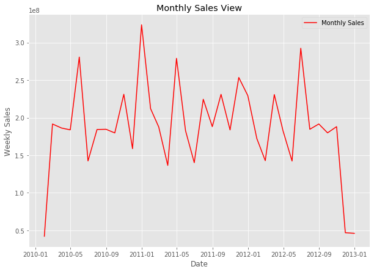

```python
style.use('ggplot')
x_mon = monthly_sales['Date']
y_mon = monthly_sales['Weekly_Sales']
fig = plt.figure(figsize = (10, 7))
plt.plot(x_mon,y_mon,color='r',label='Monthly Sales',linewidth=1.5)
plt.legend(loc='upper right')
#plt.axis([6,17,100,1750])
plt.xlabel('Date')
plt.ylabel('Weekly Sales')
plt.title('Monthly Sales View')
plt.show()
```

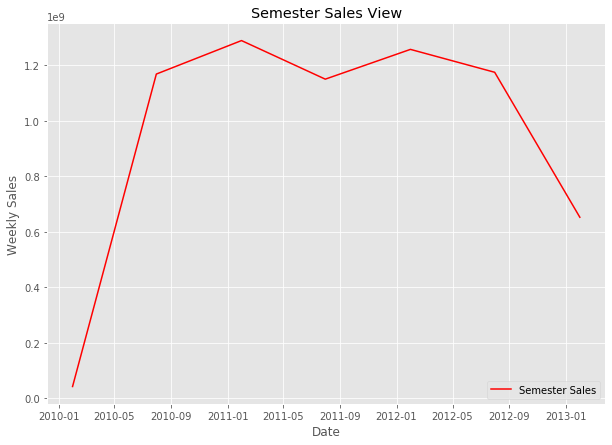

```python
style.use('ggplot')
x_sem = semester_sales['Date']
y_sem = semester_sales['Weekly_Sales']
fig = plt.figure(figsize = (10, 7))
plt.plot(x_sem,y_sem,color='r',label='Semester Sales',linewidth=1.5)
plt.legend(loc='lower right')
#plt.axis([6,17,100,1750])
plt.xlabel('Date')
plt.ylabel('Weekly Sales')
plt.title('Semester Sales View')
plt.show()
```

*Question: For Store 1 – Build prediction models to forecast demand

Linear Regression – Utilize variables like date and restructure dates as 1 for 5 Feb 2010 (starting from the earliest date in order)

```python
store1_data = df1[df1['Store'] == 1]
```

```python
store1_data.sort_values(by='Date')
store1_data
```

|  | Store | Date | Weekly_Sales | Holiday_Flag | Temperature | Fuel_Price | CPI | Unemployment |
| --- | --- | --- | --- | --- | --- | --- | --- | --- |
| 0 | 1 | 05-02-2010 | 1643690.90 | 0 | 42.31 | 2.572 | 211.096358 | 8.106 |
| 1 | 1 | 12-02-2010 | 1641957.44 | 1 | 38.51 | 2.548 | 211.242170 | 8.106 |
| 2 | 1 | 19-02-2010 | 1611968.17 | 0 | 39.93 | 2.514 | 211.289143 | 8.106 |
| 3 | 1 | 26-02-2010 | 1409727.59 | 0 | 46.63 | 2.561 | 211.319643 | 8.106 |
| 4 | 1 | 05-03-2010 | 1554806.68 | 0 | 46.50 | 2.625 | 211.350143 | 8.106 |
| ... | ... | ... | ... | ... | ... | ... | ... | ... |
| 138 | 1 | 28-09-2012 | 1437059.26 | 0 | 76.08 | 3.666 | 222.981658 | 6.908 |
| 139 | 1 | 05-10-2012 | 1670785.97 | 0 | 68.55 | 3.617 | 223.181477 | 6.573 |
| 140 | 1 | 12-10-2012 | 1573072.81 | 0 | 62.99 | 3.601 | 223.381296 | 6.573 |
| 141 | 1 | 19-10-2012 | 1508068.77 | 0 | 67.97 | 3.594 | 223.425723 | 6.573 |
| 142 | 1 | 26-10-2012 | 1493659.74 | 0 | 69.16 | 3.506 | 223.444251 | 6.573 |

143 rows × 8 columns

```python
#store1_data['Date']=pd.to_datetime(store1_data.Date)
store1_data['Date1'] = pd.to_datetime(store1_data["Date"])
store1_data['Date1'] = store1_data['Date1'].dt.strftime('%d%b%y')
```

```python
store1_data
```

|  | Store | Date | Weekly_Sales | Holiday_Flag | Temperature | Fuel_Price | CPI | Unemployment | Date1 |
| --- | --- | --- | --- | --- | --- | --- | --- | --- | --- |
| 0 | 1 | 05-02-2010 | 1643690.90 | 0 | 42.31 | 2.572 | 211.096358 | 8.106 | 02May10 |
| 1 | 1 | 12-02-2010 | 1641957.44 | 1 | 38.51 | 2.548 | 211.242170 | 8.106 | 02Dec10 |
| 2 | 1 | 19-02-2010 | 1611968.17 | 0 | 39.93 | 2.514 | 211.289143 | 8.106 | 19Feb10 |
| 3 | 1 | 26-02-2010 | 1409727.59 | 0 | 46.63 | 2.561 | 211.319643 | 8.106 | 26Feb10 |
| 4 | 1 | 05-03-2010 | 1554806.68 | 0 | 46.50 | 2.625 | 211.350143 | 8.106 | 03May10 |
| ... | ... | ... | ... | ... | ... | ... | ... | ... | ... |
| 138 | 1 | 28-09-2012 | 1437059.26 | 0 | 76.08 | 3.666 | 222.981658 | 6.908 | 28Sep12 |
| 139 | 1 | 05-10-2012 | 1670785.97 | 0 | 68.55 | 3.617 | 223.181477 | 6.573 | 10May12 |
| 140 | 1 | 12-10-2012 | 1573072.81 | 0 | 62.99 | 3.601 | 223.381296 | 6.573 | 10Dec12 |
| 141 | 1 | 19-10-2012 | 1508068.77 | 0 | 67.97 | 3.594 | 223.425723 | 6.573 | 19Oct12 |
| 142 | 1 | 26-10-2012 | 1493659.74 | 0 | 69.16 | 3.506 | 223.444251 | 6.573 | 26Oct12 |

143 rows × 9 columns

```python
date_obj = store1_data[['Date']]
```

```python
store1_data1 = store1_data
```

```python
store1_data1.Date = date_obj.index + 1
```

```python
store1_data1
```

|  | Store | Date | Weekly_Sales | Holiday_Flag | Temperature | Fuel_Price | CPI | Unemployment | Date1 |
| --- | --- | --- | --- | --- | --- | --- | --- | --- | --- |
| 0 | 1 | 1 | 1643690.90 | 0 | 42.31 | 2.572 | 211.096358 | 8.106 | 02May10 |
| 1 | 1 | 2 | 1641957.44 | 1 | 38.51 | 2.548 | 211.242170 | 8.106 | 02Dec10 |
| 2 | 1 | 3 | 1611968.17 | 0 | 39.93 | 2.514 | 211.289143 | 8.106 | 19Feb10 |
| 3 | 1 | 4 | 1409727.59 | 0 | 46.63 | 2.561 | 211.319643 | 8.106 | 26Feb10 |
| 4 | 1 | 5 | 1554806.68 | 0 | 46.50 | 2.625 | 211.350143 | 8.106 | 03May10 |
| ... | ... | ... | ... | ... | ... | ... | ... | ... | ... |
| 138 | 1 | 139 | 1437059.26 | 0 | 76.08 | 3.666 | 222.981658 | 6.908 | 28Sep12 |
| 139 | 1 | 140 | 1670785.97 | 0 | 68.55 | 3.617 | 223.181477 | 6.573 | 10May12 |
| 140 | 1 | 141 | 1573072.81 | 0 | 62.99 | 3.601 | 223.381296 | 6.573 | 10Dec12 |
| 141 | 1 | 142 | 1508068.77 | 0 | 67.97 | 3.594 | 223.425723 | 6.573 | 19Oct12 |
| 142 | 1 | 143 | 1493659.74 | 0 | 69.16 | 3.506 | 223.444251 | 6.573 | 26Oct12 |

143 rows × 9 columns

**Question: Hypothesize if CPI, unemployment, and fuel price have any impact on sales.

```python
store1_data.describe().T
```

|  | count | mean | std | min | 25% | 50% | 75% | max |
| --- | --- | --- | --- | --- | --- | --- | --- | --- |
| Store | 143.0 | 1.000000e+00 | 0.000000 | 1.000000e+00 | 1.000000e+00 | 1.000000e+00 | 1.000000e+00 | 1.000000e+00 |
| Weekly_Sales | 143.0 | 1.555264e+06 | 155980.767761 | 1.316899e+06 | 1.458105e+06 | 1.534850e+06 | 1.614892e+06 | 2.387950e+06 |
| Holiday_Flag | 143.0 | 6.993007e-02 | 0.255926 | 0.000000e+00 | 0.000000e+00 | 0.000000e+00 | 0.000000e+00 | 1.000000e+00 |
| Temperature | 143.0 | 6.830678e+01 | 14.250486 | 3.540000e+01 | 5.826500e+01 | 6.964000e+01 | 8.048500e+01 | 9.165000e+01 |
| Fuel_Price | 143.0 | 3.219699e+00 | 0.427313 | 2.514000e+00 | 2.764500e+00 | 3.290000e+00 | 3.594000e+00 | 3.907000e+00 |
| CPI | 143.0 | 2.159969e+02 | 4.350890 | 2.103374e+02 | 2.115493e+02 | 2.154599e+02 | 2.205313e+02 | 2.234443e+02 |
| Unemployment | 143.0 | 7.610420e+00 | 0.383749 | 6.573000e+00 | 7.348000e+00 | 7.787000e+00 | 7.838000e+00 | 8.106000e+00 |

```python
store1_data.isnull().sum()
```

```
Store           0
Date            0
Weekly_Sales    0
Holiday_Flag    0
Temperature     0
Fuel_Price      0
CPI             0
Unemployment    0
Date1           0
dtype: int64
```

```python
feature =store1_data[['CPI','Unemployment','Fuel_Price']]
#feature =store1_data[['CPI']]
target = store1_data[['Weekly_Sales']]
```

```python
feature.shape
target.shape
```

```
(143, 1)
```

```python
from sklearn.model_selection import train_test_split
```

```python
feature_train,feature_test,target_train,target_test = train_test_split(feature, target , test_size = 0.1 , random_state = 10)
```

```python
print(feature_train.shape)
print(feature_test.shape)
print(target_train.shape)
print(target_test.shape)
```

```
(128, 3)
(15, 3)
(128, 1)
(15, 1)
```

```python
from sklearn.preprocessing import StandardScaler
sc = StandardScaler()
feature_train = sc.fit_transform(feature_train)
feature_test = sc.transform(feature_test)
target_train = sc.fit_transform(target_train)
target_test = sc.transform(target_test)
```

```python
from sklearn.linear_model import LinearRegression
model_lr = LinearRegression()
```

```python
model_lr.fit(feature_train,target_train)
```

```
LinearRegression(copy_X=True, fit_intercept=True, n_jobs=None, normalize=False)
```

```python
print("The intercept for the LR model is : " ,model_lr.intercept_)
```

```
The intercept for the LR model is :  [-8.12916445e-17]
```

```python
print("The Coefficient for the LR model is : ",model_lr.coef_)
```

```
The Coefficient for the LR model is :  [[ 0.58290905  0.31181617 -0.14177795]]
```

```python
target_pred_test = model_lr.predict(feature_test)
```

```python
target_pred_testD = pd.DataFrame(target_pred_test)
target_test.reset_index(drop = True)
```

```python
print("The actual Target Test Values are : " ,target_test )
```

[output not shown]

```python
print("The Predicted Target Test Values are : " ,target_pred_test )
```

[output not shown]

```python
from sklearn.metrics import mean_squared_error

import numpy as np

print ('RMSE value of testing dataset')

print(np.sqrt(mean_squared_error(target_test,target_pred_test)))
```

```
RMSE value of testing dataset
0.5233245518819372
```

```python
print("R2 score is : {}".format(model_lr.score(feature_test,target_test)))
```

```
R2 score is : 0.10724830632291327
```

```python
mean_squared_error(target_test, target_pred_test)
```

```
0.2738685866024303
```

The Coefficient for the LR model is "'CPI','Unemployment','Fuel_Price'": [[ 0.58290905 0.31181617 -0.14177795]]

Fuel price has a negative impact on sales and CPI, Unemployment has a positive corelation with Sales

**Question: Change dates into days by creating new variable.**

```python
store1_data2 = df1
```

```python
store1_data2['Day_Name'] = pd.to_datetime(df1['Date']).dt.day_name()
```

```python
store1_data2.head()
```

|  | Store | Date | Weekly_Sales | Holiday_Flag | Temperature | Fuel_Price | CPI | Unemployment | Day_Name |
| --- | --- | --- | --- | --- | --- | --- | --- | --- | --- |
| 0 | 1 | 05-02-2010 | 1643690.90 | 0 | 42.31 | 2.572 | 211.096358 | 8.106 | Sunday |
| 1 | 1 | 12-02-2010 | 1641957.44 | 1 | 38.51 | 2.548 | 211.242170 | 8.106 | Thursday |
| 2 | 1 | 19-02-2010 | 1611968.17 | 0 | 39.93 | 2.514 | 211.289143 | 8.106 | Friday |
| 3 | 1 | 26-02-2010 | 1409727.59 | 0 | 46.63 | 2.561 | 211.319643 | 8.106 | Friday |
| 4 | 1 | 05-03-2010 | 1554806.68 | 0 | 46.50 | 2.625 | 211.350143 | 8.106 | Monday |